# Extract 2D Road Geometry from ArcGIS REST Service

Xiaoming Yang, Ph.D., P.E.

2023-12-20

This article introduces the procedure of using R to extract 2D road geometry data from a public ArcGIS REST service. The benefit of doing so is to avoid downloading the whole GIS files (sometimes in Gigabites), especially when only a subset of data is needed.

The method was originally posted in a [blog](https://community.esri.com/t5/gis-life-blog/accessing-arcgis-rest-services-using-r/ba-p/898451) on the esri community website. The main modification here is that the httr2 package is used instead of the httr.

First, find the REST service that has the road geometry data. For example,

- [FHWA](https://www.fhwa.dot.gov/policyinformation/hpms/shapefiles.cfm)
- [US Census](https://services.arcgis.com/P3ePLMYs2RVChkJx/ArcGIS/rest/services/TIGER_Roads_2021_view/FeatureServer).

Next, study the GIS data structure (layers, fields, codes, etc.) of the source, and develop a strategy to query the desired data. Two example codes are provided below to extract the 2D shape of I-75 in Bartow County Georgia.

### Example 1: FHWA Data

Since the I-75 is the only interstate highway in Bartow County, we can filter the road based on county code ‘15’ and functional class ‘1’.

```r
library(httr2)
library(sf)
url <- url_parse("https://geo.dot.gov/server/rest/services")
url$path <- paste(url$path, "Hosted/HPMS_FULL_GA_2020/FeatureServer/0/query", sep = "/")
url$query <- list(where = "COUNTY_CODE = 15 and F_SYSTEM = 1",
                  outFields = "*",
                  returnGeometry = "true",
                  f = "geojson")
request <- url_build(url)
roads <- st_read(request)
```

```
## replacing null geometries with empty geometries
## Simple feature collection with 749 features and 76 fields (with 8 geometries empty)
## Geometry type: LINESTRING
## Dimension:     XY
## Bounding box:  xmin: -84.91903 ymin: 34.07971 xmax: -84.65923 ymax: 34.39873
## Geodetic CRS:  WGS 84
```

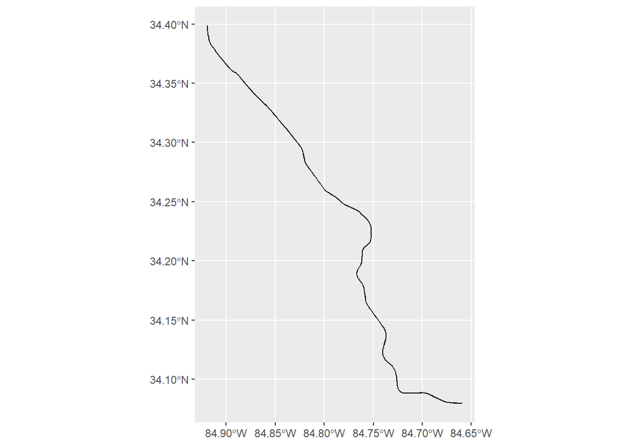

```r
library(ggplot2)
ggplot() +
  geom_sf(data = roads)
```

### Example 2 US Census Data

In TIGERWeb data, interstate highway is coded as RTTYP = ‘I’. When the location of the road cannot be filtered from the attributes, we can define a bounding box in the ‘geometry’ parameter of the query.

```r
library(httr2)
library(sf)
url <- url_parse("https://services.arcgis.com/P3ePLMYs2RVChkJx/ArcGIS/rest/services")
url$path <- paste(url$path, "TIGER_Roads_2021_view/FeatureServer/0/query", sep = "/")
url$query <- list(where = "RTTYP = 'I'",
                  geometryType = "esriGeometryEnvelope",
                  geometry = "-85.05,34.08,-84.66,34.39",
                  spatialRel="esriSpatialRelEnvelopeIntersects",
                  outFields = "*",
                  returnGeometry = "true",
                  f = "geojson")
request <- url_build(url)
roads<-st_read(request)
```

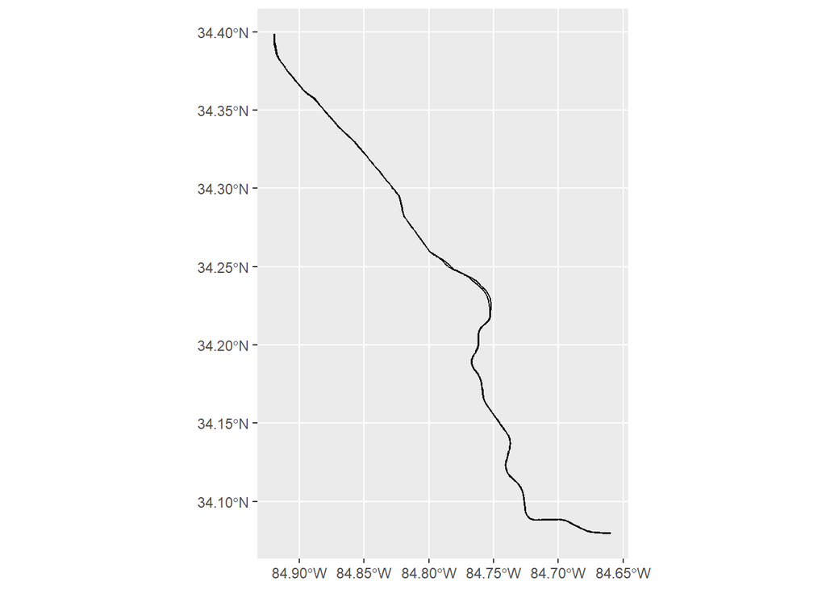

```r
library(ggplot2)
ggplot() +
  geom_sf(data = roads)
```

Footnotes:

There are a few other solutions in R.

- The ‘tigris’ package can also be used to extract the most updated US Census road data
- The ‘googleway’ package can be used to extract google road data.
- The ‘osmdata’ package can be used to extract OpenStreetMap road data.